# STAT 5000: Statistical Methods and Applications I

## Project Topic : Data Driven Analysis of New York Taxi

### Team Members :

Adarsh Mahor

Manish Vankudre

Kalp Mepani

Mayuresh Dongare

Juily Pachundkar

### Importing Data

```python
#!pip install pyarrow

import pandas as pd
import numpy as np
from scipy.stats import norm
import statsmodels.api as sm
import seaborn as sns
import matplotlib.pyplot as plt



import warnings
warnings.simplefilter("ignore")
```

```python
df = pd.read_parquet('yellow_tripdata_2023-09.parquet')
```

```python
df.head()
```

|  | VendorID | tpep_pickup_datetime | tpep_dropoff_datetime | passenger_count | trip_distance | RatecodeID | store_and_fwd_flag | PULocationID | DOLocationID | payment_type | fare_amount | extra | mta_tax | tip_amount | tolls_amount | improvement_surcharge | total_amount | congestion_surcharge | Airport_fee |
| --- | --- | --- | --- | --- | --- | --- | --- | --- | --- | --- | --- | --- | --- | --- | --- | --- | --- | --- | --- |
| 0 | 1 | 2023-09-01 00:15:37 | 2023-09-01 00:20:21 | 1.0 | 0.80 | 1.0 | N | 163 | 230 | 2 | 6.5 | 3.5 | 0.5 | 0.00 | 0.0 | 1.0 | 11.50 | 2.5 | 0.00 |
| 1 | 2 | 2023-09-01 00:18:40 | 2023-09-01 00:30:28 | 2.0 | 2.34 | 1.0 | N | 236 | 233 | 1 | 14.2 | 1.0 | 0.5 | 2.00 | 0.0 | 1.0 | 21.20 | 2.5 | 0.00 |
| 2 | 2 | 2023-09-01 00:35:01 | 2023-09-01 00:39:04 | 1.0 | 1.62 | 1.0 | N | 162 | 236 | 1 | 8.6 | 1.0 | 0.5 | 2.00 | 0.0 | 1.0 | 15.60 | 2.5 | 0.00 |
| 3 | 2 | 2023-09-01 00:45:45 | 2023-09-01 00:47:37 | 1.0 | 0.74 | 1.0 | N | 141 | 229 | 1 | 5.1 | 1.0 | 0.5 | 1.00 | 0.0 | 1.0 | 11.10 | 2.5 | 0.00 |
| 4 | 2 | 2023-09-01 00:01:23 | 2023-09-01 00:38:05 | 1.0 | 9.85 | 1.0 | N | 138 | 230 | 1 | 45.0 | 6.0 | 0.5 | 17.02 | 0.0 | 1.0 | 73.77 | 2.5 | 1.75 |

### Data Cleaning

```python
def remove_outliers(df, column_name, threshold=2.5):
    mean_value = df[column_name].mean()
    std_value = df[column_name].std()
    df_filtered = df[abs(df[column_name] - mean_value) < threshold * std_value]
    return df_filtered
```

```python
def clean_df(df):

    df = df[(df['tip_amount'] > 0)]
    df = df[(df['total_amount'] > 0)]
    df = df[(df['fare_amount'] > 0)]
    df = df[(df['trip_distance'] > 0.3)]

    df = remove_outliers(df, 'trip_distance')
    df = remove_outliers(df, 'tip_amount')

    df['cost_per_mile'] = df['fare_amount'] / df['trip_distance']

    df = remove_outliers(df, 'cost_per_mile')

    df = df.dropna()

    return df
```

```python
nyc_taxi = clean_df(df)
nyc_taxi.head()
```

|  | VendorID | tpep_pickup_datetime | tpep_dropoff_datetime | passenger_count | trip_distance | RatecodeID | store_and_fwd_flag | PULocationID | DOLocationID | payment_type | fare_amount | extra | mta_tax | tip_amount | tolls_amount | improvement_surcharge | total_amount | congestion_surcharge | Airport_fee | cost_per_mile |
| --- | --- | --- | --- | --- | --- | --- | --- | --- | --- | --- | --- | --- | --- | --- | --- | --- | --- | --- | --- | --- |
| 1 | 2 | 2023-09-01 00:18:40 | 2023-09-01 00:30:28 | 2.0 | 2.34 | 1.0 | N | 236 | 233 | 1 | 14.2 | 1.0 | 0.5 | 2.00 | 0.0 | 1.0 | 21.20 | 2.5 | 0.0 | 6.068376 |
| 2 | 2 | 2023-09-01 00:35:01 | 2023-09-01 00:39:04 | 1.0 | 1.62 | 1.0 | N | 162 | 236 | 1 | 8.6 | 1.0 | 0.5 | 2.00 | 0.0 | 1.0 | 15.60 | 2.5 | 0.0 | 5.308642 |
| 3 | 2 | 2023-09-01 00:45:45 | 2023-09-01 00:47:37 | 1.0 | 0.74 | 1.0 | N | 141 | 229 | 1 | 5.1 | 1.0 | 0.5 | 1.00 | 0.0 | 1.0 | 11.10 | 2.5 | 0.0 | 6.891892 |
| 6 | 1 | 2023-09-01 00:51:50 | 2023-09-01 01:10:21 | 0.0 | 10.90 | 1.0 | N | 93 | 255 | 1 | 41.5 | 1.0 | 0.5 | 3.00 | 0.0 | 1.0 | 47.00 | 0.0 | 0.0 | 3.807339 |
| 7 | 1 | 2023-09-01 00:01:04 | 2023-09-01 00:18:36 | 1.0 | 3.90 | 1.0 | N | 140 | 7 | 1 | 20.5 | 3.5 | 0.5 | 6.35 | 0.0 | 1.0 | 31.85 | 2.5 | 0.0 | 5.256410 |

```python
nyc_taxi.count()
```

```
VendorID                 1929158
tpep_pickup_datetime     1929158
tpep_dropoff_datetime    1929158
passenger_count          1929158
trip_distance            1929158
RatecodeID               1929158
store_and_fwd_flag       1929158
PULocationID             1929158
DOLocationID             1929158
payment_type             1929158
fare_amount              1929158
extra                    1929158
mta_tax                  1929158
tip_amount               1929158
tolls_amount             1929158
improvement_surcharge    1929158
total_amount             1929158
congestion_surcharge     1929158
Airport_fee              1929158
cost_per_mile            1929158
dtype: int64
```

### Data Visualization

```python
import matplotlib.pyplot as plt
import seaborn as sns

def plot_distributions_before_after(df_before, df_after, column_name, xlabel):
    plt.figure(figsize=(12, 6))

    # Plot before removing outliers
    plt.subplot(1, 2, 1)
    sns.histplot(df_before[column_name], bins=30, kde=True, color='blue')
    plt.title(f'Distribution of {column_name} before removing outliers')
    plt.xlabel(xlabel)
    plt.ylabel('Frequency')

    # Plot after removing outliers
    plt.subplot(1, 2, 2)
    sns.histplot(df_after[column_name], bins=30, kde=True, color='green')
    plt.title(f'Distribution of {column_name} after removing outliers')
    plt.xlabel(xlabel)
    plt.ylabel('Frequency')

    plt.tight_layout()
    plt.show()
```

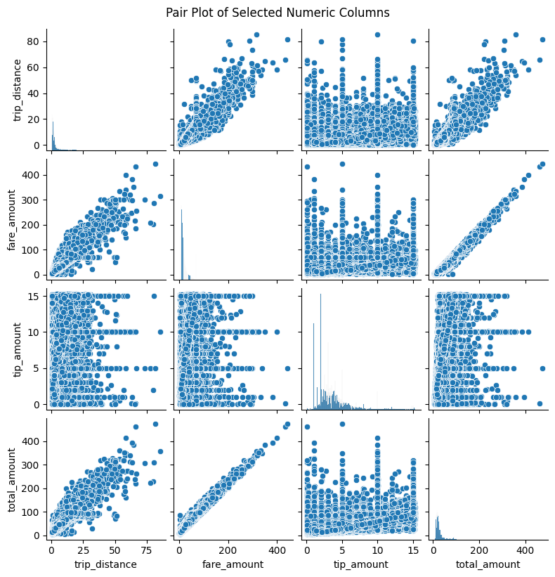

```python
plt.figure(figsize=(12, 10))
selected_columns = ['trip_distance', 'fare_amount', 'tip_amount', 'total_amount']
sns.pairplot(nyc_taxi[selected_columns], height=2)
plt.suptitle('Pair Plot of Selected Numeric Columns', y=1.02)
plt.show()
```

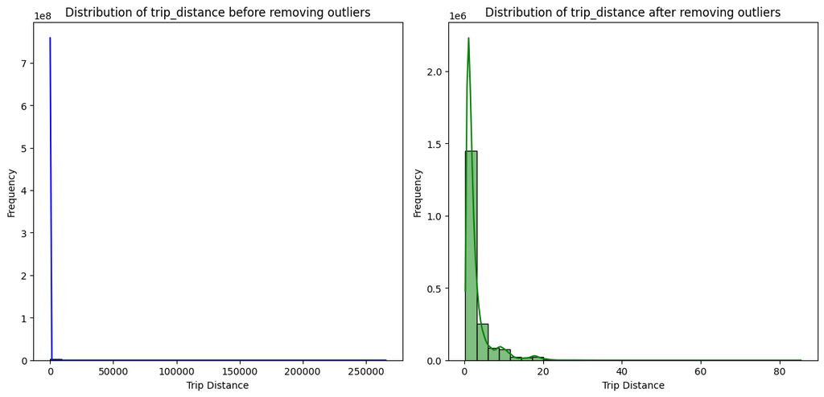

```python
plot_distributions_before_after(df, nyc_taxi, 'trip_distance', 'Trip Distance')
```

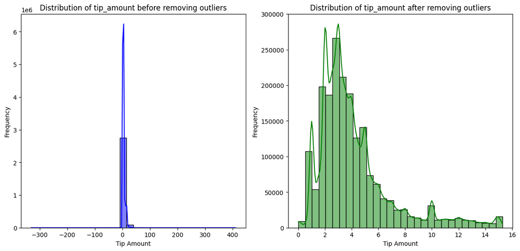

```python
plot_distributions_before_after(df, nyc_taxi, 'tip_amount', 'Tip Amount')
```

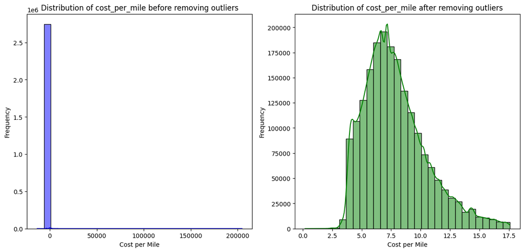

```python
df_before = df.copy()
df1 = df_before.copy()

df1['cost_per_mile'] = df1['fare_amount'] / df1['trip_distance']

plot_distributions_before_after(df1, nyc_taxi, 'cost_per_mile', 'Cost per Mile')
```

### Hypothesis 1: Cost per Mile Amounts Differs Between Taxi Providers

Null Hypothesis (H0) : $\mu_1 = \mu_2$

There is no significant difference in the average cost per mile amounts between taxi trips provided by Vendor 1 and Vendor 2.

Alternative Hypothesis (H1) : $\mu_1 \neq \mu_2$

Average cost per mile amounts vary between taxi trips provided by Vendor 1 and Vendor 2.

Here, $\mu_1$ represents the population mean of the cost per mile for Vendor 1, and $\mu_2$ represents the population mean of the cost per mile for Vendor 2.

```python
import numpy as np
import pandas as pd
from scipy import stats

tpep_providers = sorted(nyc_taxi['VendorID'].unique())

num_simulations = 100
accept_count = 0

alpha = 0.05
rs = 1

for _ in range(num_simulations):
    fare_by_provider = {}
    np.random.seed(rs)
    rs += 1

    for provider in tpep_providers:
        provider_data = nyc_taxi[nyc_taxi['VendorID'] == provider]['cost_per_mile']
        fare_by_provider[provider] = provider_data.sample(1000)

    t_statistic, p_value = stats.ttest_ind(*fare_by_provider.values(), equal_var=False)

    if p_value > alpha:
        accept_count += 1

proportion_accept = accept_count / num_simulations

print(f"Proportion of acceptance out of {num_simulations} simulations: {proportion_accept:.2%}")

if proportion_accept > 0.5:
    print("Reject the null hypothesis. Average cost per mile amounts vary between taxi trips provided by Vendor 1 and Vendor 2.")
else:
    print("Fail to reject the null hypothesis. There is no significant difference in the average cost per mile amounts between taxi trips provided by Vendor 1 and Vendor 2.")
```

[output not shown]

#### Hypothesis 1 Normal Distribution Plot

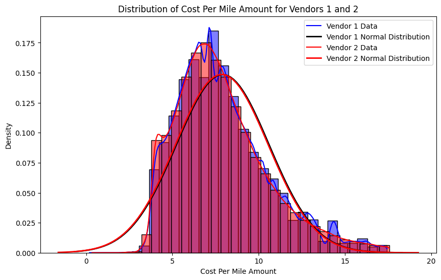

```python
import matplotlib.pyplot as plt
import seaborn as sns
from scipy.stats import norm
import numpy as np

plt.figure(figsize=(10, 6))

sns.histplot(nyc_taxi[nyc_taxi['VendorID'] == 1]['cost_per_mile'], kde=True, color='blue', bins=30, stat='density')

mu, std = norm.fit(nyc_taxi[nyc_taxi['VendorID'] == 1]['cost_per_mile'])
xmin, xmax = plt.xlim()
x = np.linspace(xmin, xmax, 100)
p = norm.pdf(x, mu, std)
plt.plot(x, p, 'k', linewidth=2)

sns.histplot(nyc_taxi[nyc_taxi['VendorID'] == 2]['cost_per_mile'], kde=True, color='red', bins=30, stat='density', alpha = 0.5)

mu, std = norm.fit(nyc_taxi[nyc_taxi['VendorID'] == 2]['cost_per_mile'])
xmin, xmax = plt.xlim()
x = np.linspace(xmin, xmax, 100)
p = norm.pdf(x, mu, std)
plt.plot(x, p, 'r', linewidth=2)

plt.title('Distribution of Cost Per Mile Amount for Vendors 1 and 2')
plt.xlabel('Cost Per Mile Amount')
plt.ylabel('Density')

plt.legend(['Vendor 1 Data', 'Vendor 1 Normal Distribution', 'Vendor 2 Data', 'Vendor 2 Normal Distribution'])
plt.show()
```

### Hypothesis 2: Tip Amount Differs Between Taxi Providers

Null Hypothesis (H0) : $\mu_1 = \mu_2$

There is no significant difference in the average tip amounts between taxi trips provided by Vendor 1 and Vendor 2.

Alternative Hypothesis (H1) : $\mu_1 \neq \mu_2$

Average tip amounts vary between taxi trips provided by Vendor 1 and Vendor 2.

Here, $\mu_1$ represents the population mean of the tip amount for Vendor 1, and $\mu_2$ represents the population mean of the tip amount for Vendor 2.

```python
import numpy as np
import scipy.stats as stats

tpep_providers = sorted(nyc_taxi['VendorID'].unique())

num_simulations = 100
accept_count = 0

alpha = 0.05
rs = 1

for _ in range(num_simulations):
    fare_by_provider = {}
    np.random.seed(rs)
    rs += 1

    for provider in tpep_providers:
        provider_data = nyc_taxi[nyc_taxi['VendorID'] == provider]['tip_amount']
        fare_by_provider[provider] = provider_data.sample(1000)

    t_statistic, p_value = stats.ttest_ind(*fare_by_provider.values(), equal_var=False)

    if p_value > alpha:
        accept_count += 1

proportion_accept = accept_count / num_simulations

print(f"Proportion of acceptancections out of {num_simulations} simulations: {proportion_accept:.2%}")

if proportion_accept > 0.5:
    print("Reject the null hypothesis. Average tip amounts vary between taxi trips provided by Vendor 1 and Vendor 2.")
else:
    print("Fail to reject the null hypothesis. There is no significant difference in the average tip amounts between taxi trips provided by Vendor 1 and Vendor 2.")
```

[output not shown]

#### Hypothesis 2 Normal Distribution Plot

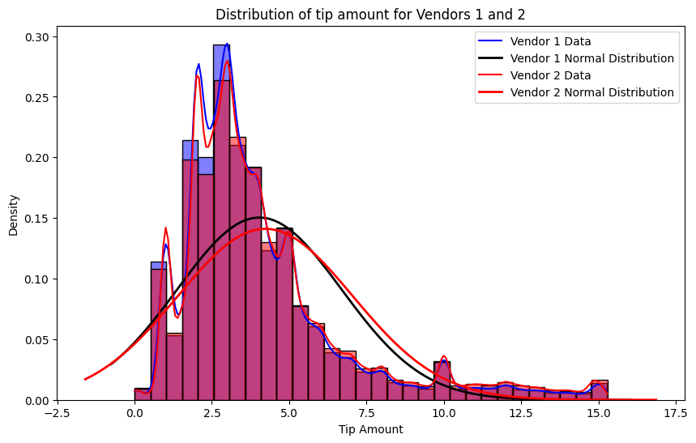

```python
import matplotlib.pyplot as plt
import seaborn as sns
from scipy.stats import norm
import numpy as np

plt.figure(figsize=(10, 6))

sns.histplot(nyc_taxi[nyc_taxi['VendorID'] == 1]['tip_amount'], kde=True, color='blue', bins=30, stat='density')

mu, std = norm.fit(nyc_taxi[nyc_taxi['VendorID'] == 1]['tip_amount'])
xmin, xmax = plt.xlim()
x = np.linspace(xmin, xmax, 100)
p = norm.pdf(x, mu, std)
plt.plot(x, p, 'k', linewidth=2)

sns.histplot(nyc_taxi[nyc_taxi['VendorID'] == 2]['tip_amount'], kde=True, color='red', bins=30, stat='density', alpha = 0.5)

mu, std = norm.fit(nyc_taxi[nyc_taxi['VendorID'] == 2]['tip_amount'])
xmin, xmax = plt.xlim()
x = np.linspace(xmin, xmax, 100)
p = norm.pdf(x, mu, std)
plt.plot(x, p, 'r', linewidth=2)

plt.title('Distribution of tip amount for Vendors 1 and 2')
plt.xlabel('Tip Amount')
plt.ylabel('Density')

plt.legend(['Vendor 1 Data', 'Vendor 1 Normal Distribution', 'Vendor 2 Data', 'Vendor 2 Normal Distribution'])
plt.show()
```